# Project: First Month of 2018 ford Gobike System

## by Kadiri Aiyegbeni Abdulkadir

- Introduction
- Data Wrangling
- visualization and Analysis

>

## Introduction

I am using the first month of 2018 ford Gobike datase.i want to investigate the impact of gender in ford Go biketrip.I am investigating the impact of gender in fordgobike system data of the first month of 2018, how gender availability in each trip?. The number of user that registered that are male or female for the trip ,and how long was the trip based on the gender.The main focus on this ford gobike trip are member_gender,duration_min,day and user_type

## Main Features

The features of Fordgobike system include:

- duration_sec
- start_time
- end_time
- start_station_id
- start_station_name
- start_station_latitude
- start_station_longitude
- end_station_id
- end_station_name
- end_station_latitude
- end_station_longitude
- bike_id
- user_type
- member_birth_year
- member_gender
- bike_share_for_all_trip

## Datasets supports

I would be using duration_sec,start_time end_time,bike_iduser_type,member_birth_year,member_gender,bike_share_for_all_trip, duration_min and day features since i am investigating the impact of gender on fordgobike trip

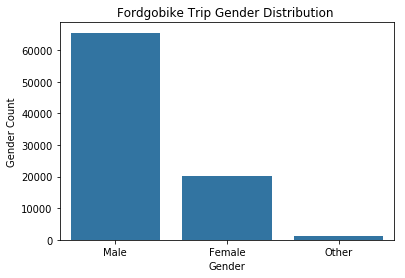

```python
#plot of gender
base_color = sb.color_palette()[0]
gender = df_clean['member_gender'].value_counts().index
sb.countplot(data = df_clean, x ='member_gender',color = base_color, order = gender)
plt.xlabel('Gender')
plt.ylabel('Gender Count')
plt.title('Fordgobike Trip Gender Distribution ')
plt.show()
```

User: on the countplot findings you can see that the number of subcriber that are fully registered is higher than the customer fordgobike system .The subscriber is more 80000 as compared to 13000 customers.

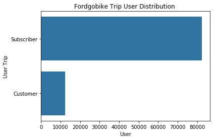

```python
# user plot
base_color = sb.color_palette()[0]
user = df_clean['user_type'].value_counts().index
sb.countplot(data = df_clean, y ='user_type',color = base_color, order = user)
plt.xlabel('User')
plt.ylabel('User Trip')
plt.title('Fordgobike Trip User Distribution ')
plt.show()
```

Day Trip : here i did plot the days of the plot, i want to know how days is related to gender impact of fordgobike trip system. as you can see the highest day for patronage in fordgobike is Tuesday wednesday, Thurdays,friday, Monday,Saturday and Sundays in that descending order.

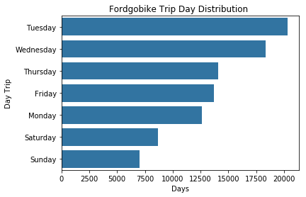

```python
# Day plot
base_color = sb.color_palette()[0]
start_order = df_clean['day'].value_counts().index
sb.countplot(data = df_clean, y='day',color = base_color, order = start_order)
plt.xlabel('Days')
plt.ylabel('Day Trip')
plt.title('Fordgobike Trip Day Distribution ')
plt.show()
```

Bike Duration: During my histogram plotting , i discover that is a skewed distribution that required scale transformation in order to get a better intepretation in relation to member_gender so that i see the gender impact on forgobike trip

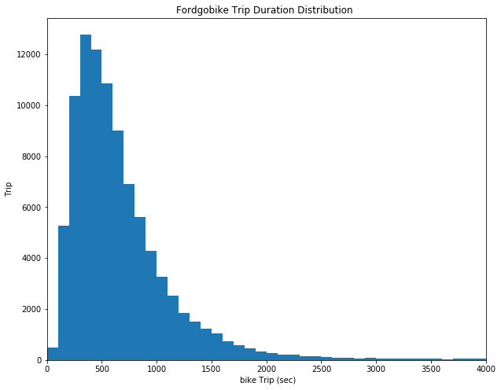

```python
# Duration_ sec plot
plt.figure(figsize = (10,8))
bin_edges =np.arange(0, df_clean['duration_sec'].max()+100,100)
plt.hist(data = df_clean, x ='duration_sec',bins = bin_edges)
plt.xlim(0, 4000)
plt.xlabel(' bike Trip (sec)')
plt.ylabel('Trip')
plt.title('Fordgobike Trip Duration Distribution ')
plt.show()
```

Bike Duration: During my histogram plotting , i discover that is a skewed distribution that required scale transformation in order to get a better intepretation in relation to member_gender so that i see the gender impact on forgobike trip

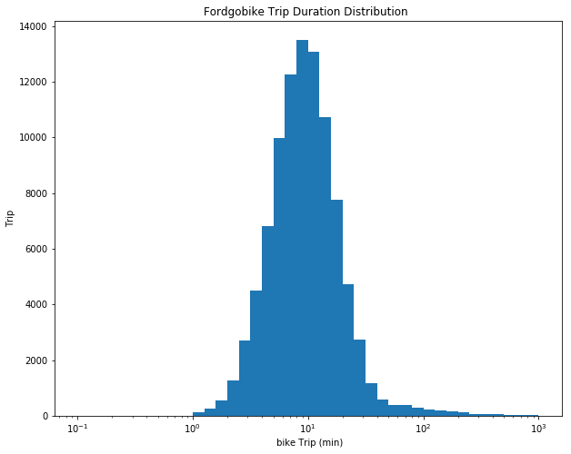

```python
# Duration_ min plot
plt.figure(figsize = (10,8))
bin_edges =10 ** np.arange(-1,3.0+0.1,0.1)
ticks = [0.1,0.3,1,3,10,30,100,300]
labels = ['{}'.format(val) for val in ticks]
plt.hist(data = df_clean, x ='duration_min',bins = bin_edges)
plt.xticks(ticks, labels)
plt.xlabel(' bike Trip (min)')
plt.ylabel('Trip')
plt.title('Fordgobike Trip Duration Distribution ')
plt.xscale('log');
```

They are more male users than any other gender as shown

```
Text(0.5,1,'Fordgobike  Gender Distribution  with respect to Users')
```

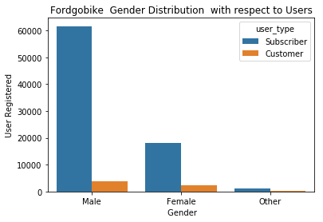

```python
#plot of gender with users registered
sb.countplot(data = df_clean , x ='member_gender',hue = 'user_type')
plt.xlabel(' Gender')
plt.ylabel('User Registered')
plt.title('Fordgobike  Gender Distribution  with respect to Users')
```

they are more availabilty of male in fordgobike trip than any other gender as shown

```
Text(0.5,1,'Fordgobike  Gender Distribution  with respect to Days')
```

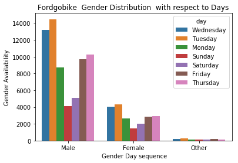

```python
#plot of gender with day
sb.countplot(data = df_clean , x ='member_gender',hue = 'day')
plt.xlabel(' Gender Day sequence')
plt.ylabel('Gender Availability')
plt.title('Fordgobike  Gender Distribution  with respect to Days')
```

```
Text(0.5,1,'Fordgobike  Gender Distribution  with respect to Users')
```

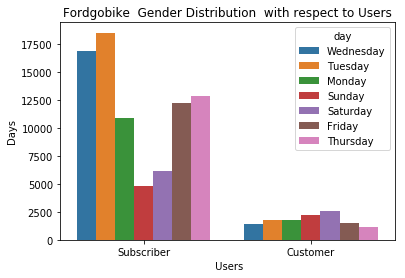

```python
#plot of   user register  with  day
sb.countplot(data = df_clean , x ='user_type',hue = 'day')
plt.xlabel(' Users')
plt.ylabel('Days')
plt.title('Fordgobike  Gender Distribution  with respect to Users')
```

gender user duration: more male subscriber spend more time in trip than the female and others but the male customeer slightly spend more trip time with the least from the others

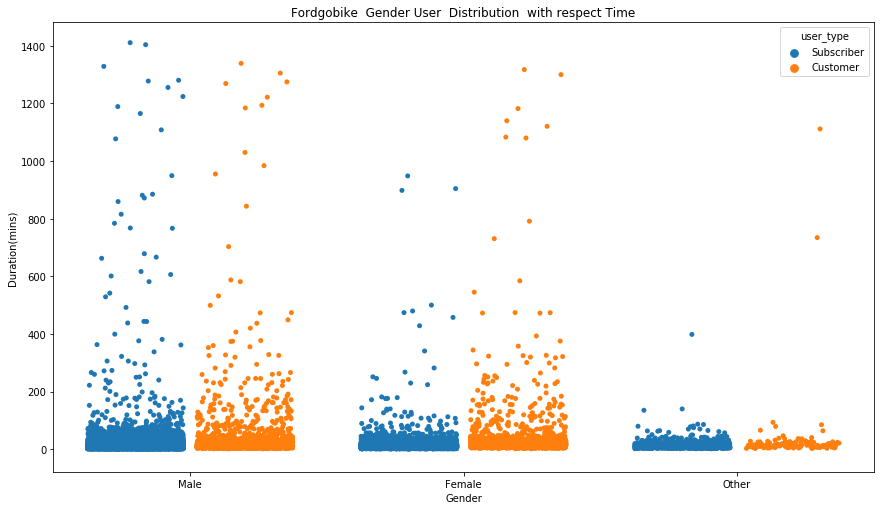

```python
#gender user duration
plt.figure(figsize=[14.70, 8.27])
sb.stripplot(data = df_clean, x = 'member_gender', y = 'duration_min', hue = 'user_type',jitter = 0.35, dodge = True)
plt.xlabel('Gender')
plt.ylabel('Duration(mins)')
plt.title('Fordgobike  Gender User  Distribution  with respect Time')
plt.show()
```

```python
!jupyter nbconvert project_final_exploration_slide--to slides --post serve --template output_toggle
```

[output not shown]

[output cut: 140 more lines]

[output not shown]

[output not shown]